# Ivan Hanigan - Disentangle Things

## All colour palettes

- The following is from http://www.compbiome.com/2010/12/r-using-rcolorbrewer-to-colour-your.html

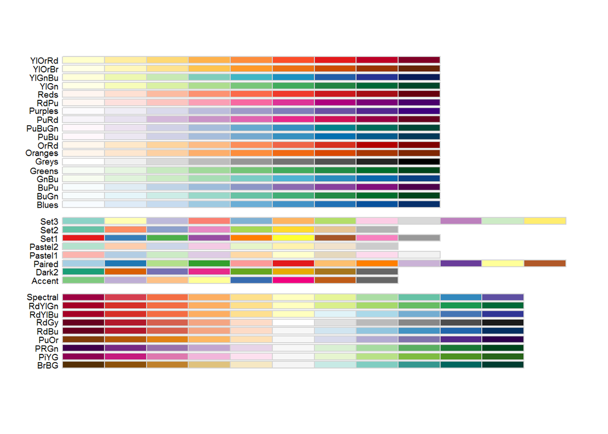

```r
### Show all the colour schemes available
par(cex = .6)
display.brewer.all()
```

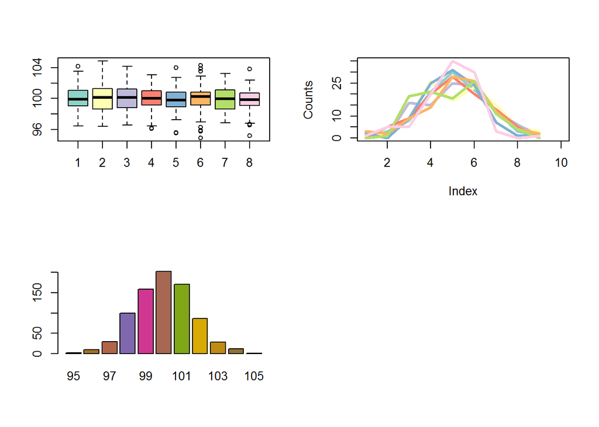

```r
### Set the display a 2 by 2 grid
par(mfrow=c(2,2))


### Generate random data matrix
rand.data <- replicate(8,rnorm(100,100,sd=1.5))

### Draw a box plot, with each box coloured by the 'Set3' palette
boxplot(rand.data,col=brewer.pal(8,"Set3"))

### Draw plot of counts coloured by the 'Set3' pallatte
br.range <- seq(min(rand.data),max(rand.data),length.out=10)
results <- sapply(1:ncol(rand.data),function(x) hist(rand.data[,x],plot=F,br=br.range)$counts)
plot(x=br.range,ylim=range(results),type="n",ylab="Counts")
cols <- brewer.pal(8,"Set3")
lapply(1:ncol(results),function(x) lines(results[,x],col=cols[x],lwd=3))

### Draw a bar chart
table.data <- table(round(rand.data))
cols <- colorRampPalette(brewer.pal(8,"Dark2"))(length(table.data))
barplot(table.data,col=cols)
```

# Other reference material

- Brewer, C. A., Hatchard, G. W., & Harrower, M. A. (2003). ColorBrewer in Print: A Catalog of Color Schemes for Maps. Cartography and Geographic Information Science, 30(1), 5–32. http://doi.org/10.1559/152304003100010929
- and Bernice E. Rogowitz and Lloyd A. Treinish of IBM Research “Why Should Engineers and Scientists Be Worried About Color?” http://www.research.ibm.com/people/l/lloydt/color/color.HTM

Posted in exploratory data analysis

03 Aug 2016

« Previous Next »

Banner Artwork by Cindy Hales. Site powered by [Jekyll](https://github.com/mojombo/jekyll) with [Carrington](http://carringtontheme.com) theme.